# Ejercicio de Clase - Creditos - Notas 3 - pag 43

### Paquetes requeridos para correr el ejercicio

### 1) Sea  la tasa de créditos hipotecarios otorgados por un banco. Durante el 2004 la tasa promedio fue de 60% y la desviación estándar de la tasa fue de 0.04. En lo que va del año 2005 se han solicitado 100 créditos, de los cuales se han otorgado únicamente 50.

Esto quiere decir que tengo como INFORMACION INICIAL lo siguiente:

$x1,...,xn$ es una m.a. proveniente de una dist Bernoulli (exito=otorgado, fracaso=no otorgado)

$f(\theta)$ Distribución Inicial

$n=100$ la muestra que tengo hoy, de los cuales se han aprobado 50.

$\sum xi=50$ Este es un estadistico, la suma de las Xis

Además me dicen: en la historia del Banco, la tasa promedio fué del 60% y la desviación de 0.04.

$E(\theta)= 0.6$

$\sigma(\theta)= 0.04$

#### a) Usando la información del año pasado, encuentra la distribución beta que mejor describe el conocimiento inicial.

$\theta$ $\~$ $Beta(a,b)$ Distribución Inicial me dicen es Beta

$E(\theta)= a/(a+b)=0.6$

$Var(\theta)= (ab)/((a+b)^2(a+b+1))=(0.04)^2$

Despejando….

a= 89.4 y b= 59.6

Entonces la distribuion inicial seria $\theta$ $\~$ $Beta(89.4,59.6)$

```r
#--- Ejemplo 1---
#-Reading data-
n<-100
credito<-c(rep(1,n/2),rep(0,n/2))
#-Defining data-
data<-list("n"=n,"x"=credito)
#-Defining inits-
inits<-function(){list(theta=0.5,x1=rep(1,2))}
#-Selecting parameters to monitor-
parameters<-c("theta","x1")
#-Running code-
#JAGS
ej1.sim<-jags(data,inits,parameters,model.file="Ej1_1.txt",
              n.iter=5000,n.chains=1,n.burnin=500,n.thin=1)
```

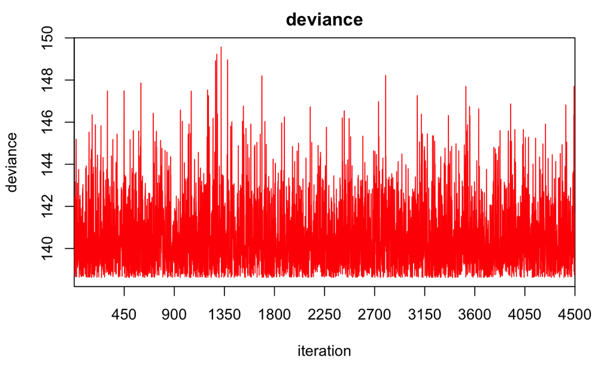

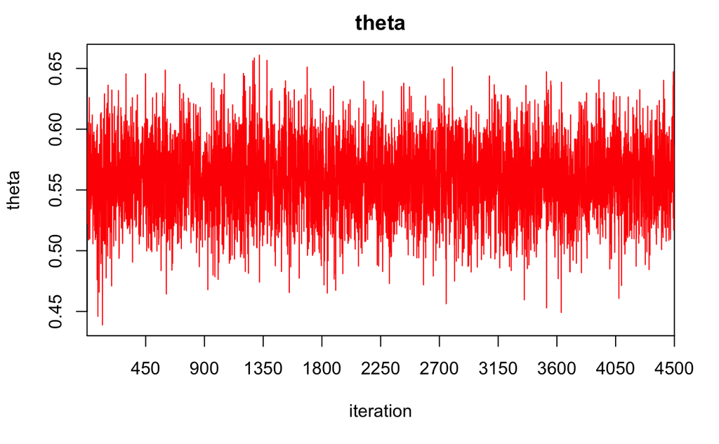

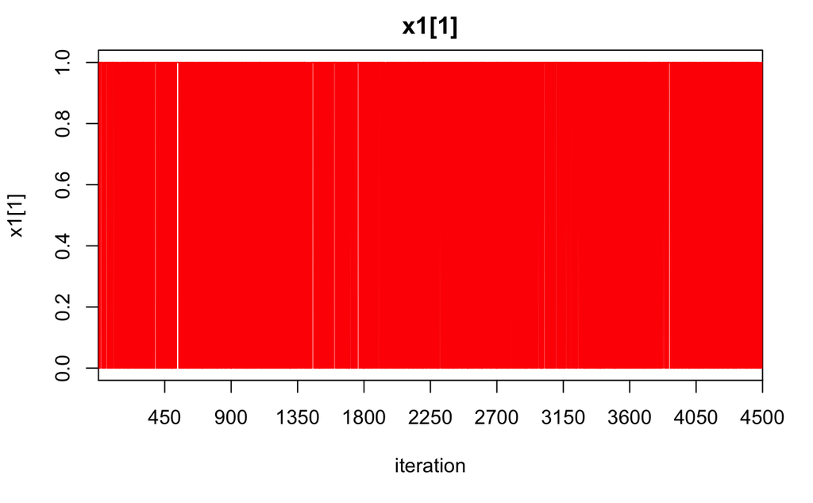

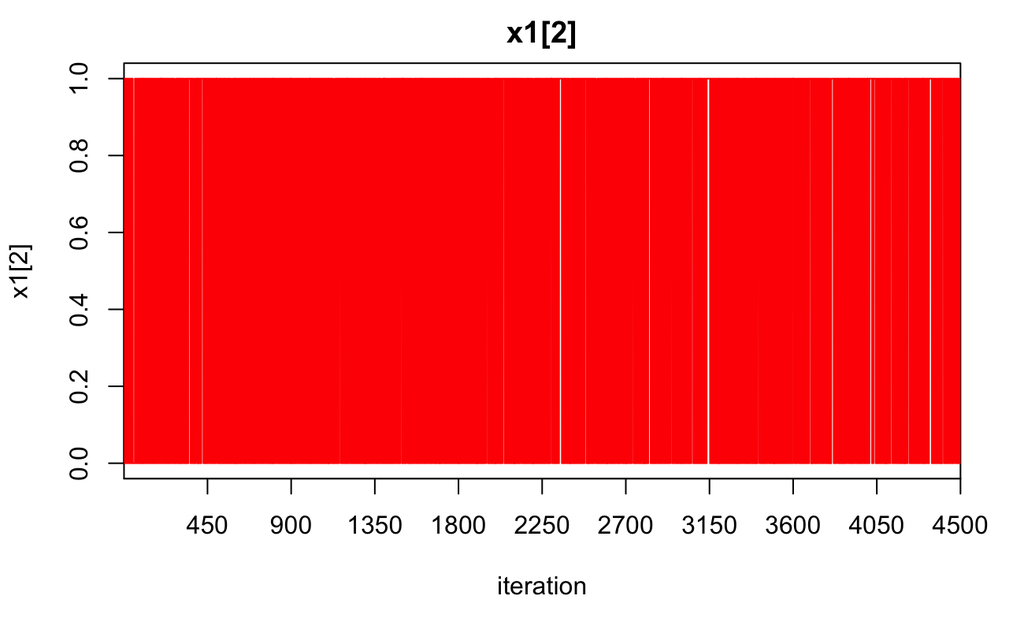

```r
#-Monitoring chain-
#Traza de la cadena
traceplot(ej1.sim)
```

```r
#Cadena
#JAGS
out<-ej1.sim$BUGSoutput$sims.list
z<-out$theta
par(mfrow=c(2,2))
plot(z,type="l")
plot(cumsum(z)/(1:length(z)),type="l")
```

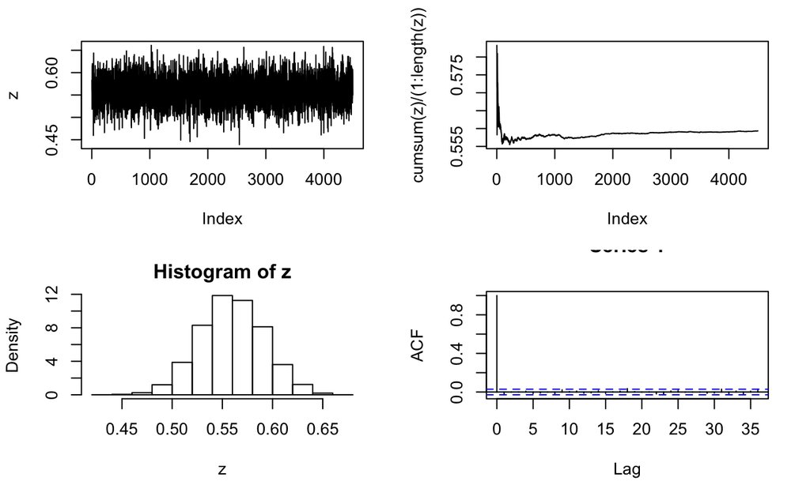

```r
hist(z,freq=FALSE)
acf(z)
```

Primer cuadro: como se está moviendo theta Segundo: como esta convergiendo o no la media. Si se mueve mucho necesito mas iteraciones. Tercero: Histograma de mi posterior. Si tengo “huecos” entonces necesito mas iteraciones porque hay espacios de mi parámetro que no estoy recorriendo Cuarto: Correlacion entre las variables simulados. En este caso es 0 (dos rayas azules muy pegadas a cero)

```r
#Resumen (estimadores)
#JAGS
out.sum<-ej1.sim$BUGSoutput$summary
print(out.sum)
```

```
                mean         sd        2.5%         25%         50%         75%       97.5%
deviance 140.4675807 1.63766293 138.6448845 139.2097299 140.0449859 141.3230344 144.7210217
theta      0.5593453 0.03160825   0.4974438   0.5378786   0.5592533   0.5815114   0.6215499
x1[1]      0.5551111 0.49700871   0.0000000   0.0000000   1.0000000   1.0000000   1.0000000
x1[2]      0.5597778 0.49646892   0.0000000   0.0000000   1.0000000   1.0000000   1.0000000
```

```r
#DIC
#JAGS
out.dic<-ej1.sim$BUGSoutput$DIC
print(out.dic)
```

```
[1] 141.8086
```

Este resumen me dice theta media 0.5593453 y un desvio standard de 0.03160825 Quantiles: para estimar con un 95% digo que Theta esta entre 0.4974438-0.6215499 DIC: 141.8086

```
Usando el archivo Ej1_1.txt
# model: Mi modelo, distribucion de los datos  - dbin(theta,1) es una Bernoulli(theta)
#Priors - Iniciales para Theta, el parametro
#Predictive: quiero que me prediga dos futuros creditos, que también proviene de una bernoulli
#Predictiva: Esta es la forma de como decirle a JAGS que prediga

model
{
for (i in 1:n) {
    x[i] ~ dbin(theta,1)
    }
#Priors
#----------
#Inciso a:
theta ~ dbeta(89.4,59.6)
# la final seria una bin-beta porque es un analisis conjugado
# RECORDAR: TODO LO QUE TIENE ~ ACA DEBE TENER UNA LINEA INIT EN R.
#Predictive
for (j in 1:2) {
    x1[j] ~ dbin(theta,1)
    }
}
```